# Assignment 6

Allison Tessman

2024-02-22

# 1. Use the codes in the slides to plot the ACF of:

- a white-noise that follows the standard normal distribution (using rnorm function)

```r
set.seed(30)

#Create a white-noise time series
y <- ts(rnorm(100))

library(ggfortify)
```

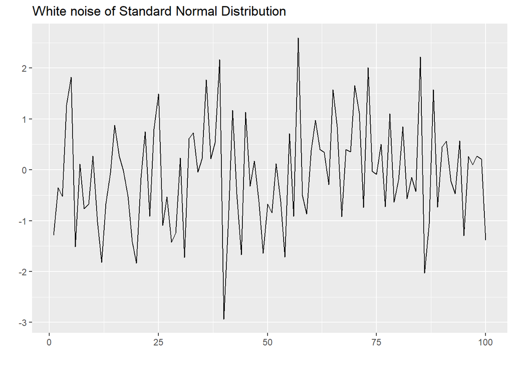

```r
autoplot(y) + ggtitle("White noise of Standard Normal Distribution")
```

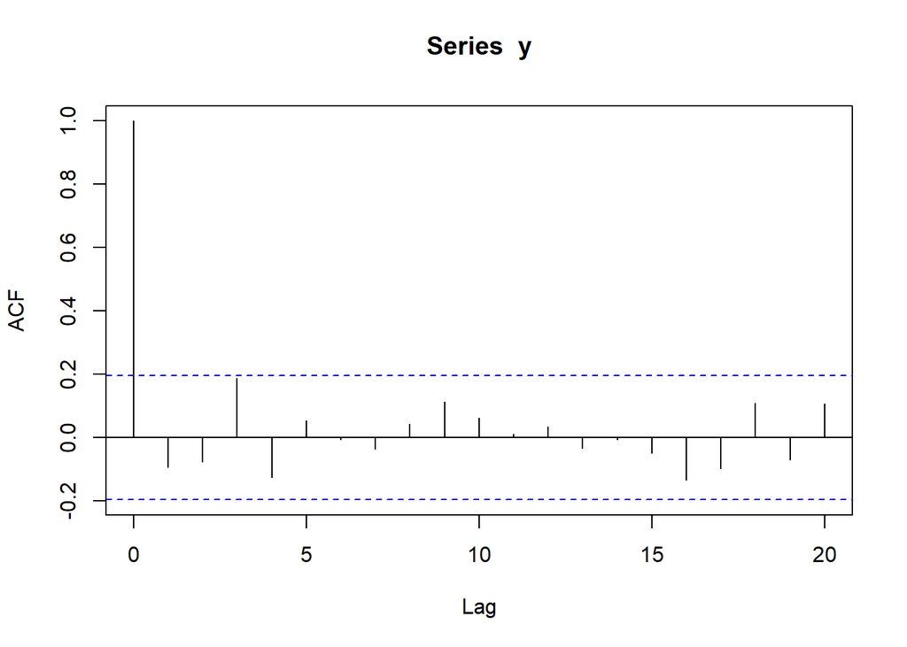

```r
#plot its ACF
acf(y)
```

- a time series with trend

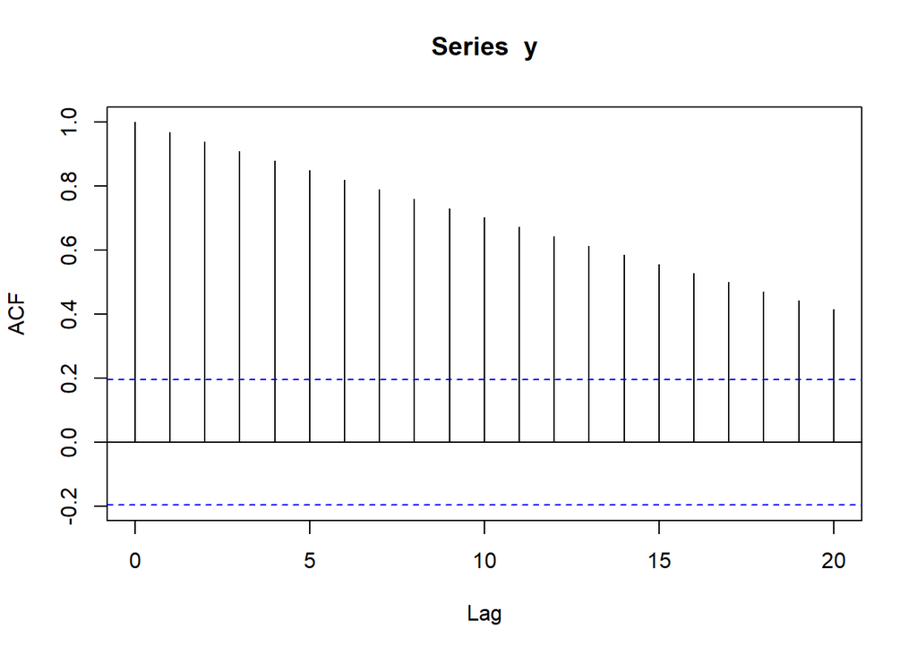

```r
y = ts(c(1:100))
acf(y)
```

- a time series with seasonality

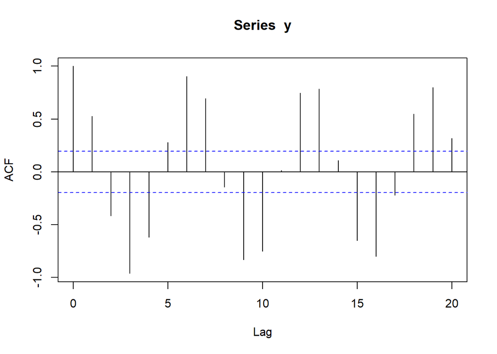

```r
set.seed(30)
y = cos(1:100)
y <- ts(y)

acf(y)
```

- a time series with trend and seasonality

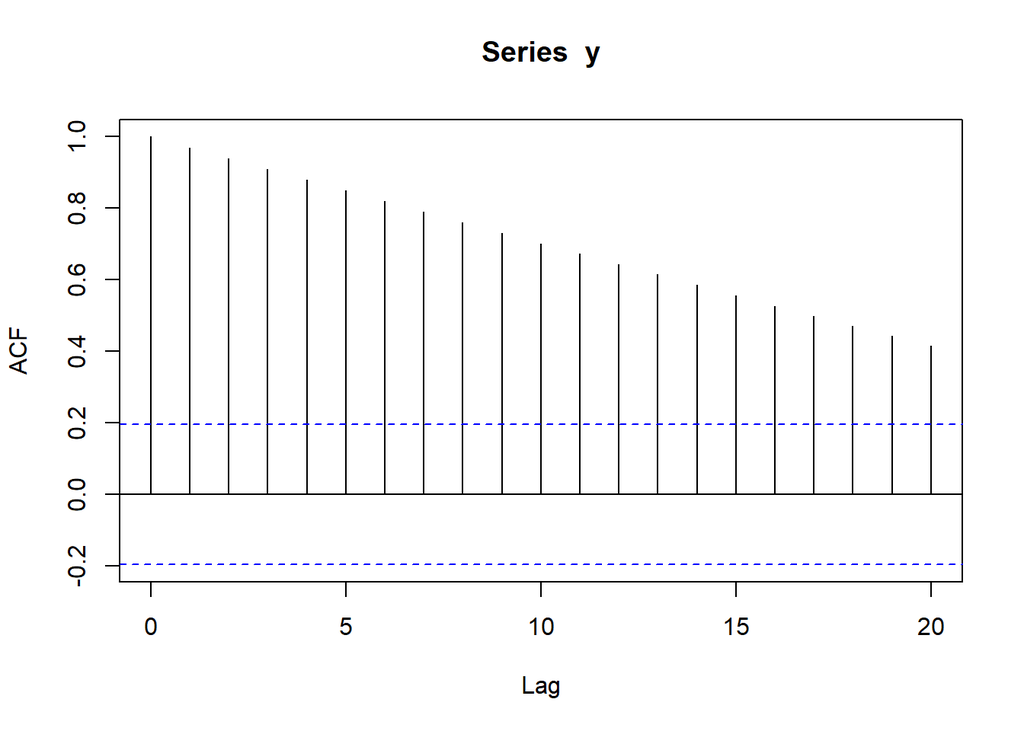

```r
y = ts(cos(c(1:100))+c(1:100))
acf(y)
```

# Comment on the difference between the ACF of the white-noise and other time series.

- The ACF of the white noise goes both positive and negative between -0.2 and 0.2, except for the first part that jumps to 1.0
- The ACF of the time series with trend shows a steady decline of the ACF from 1.0 to about 0.5, and there are no negative values
- The ACF of the time series with seasonality goes both positive and negative, but there is a pattern to it with positive values 1.0 and 0.5, then -0.5, -1.0, and -0.75, and then the plot returns to positive values of similar height.

# 2. Use the codes in the slides to simulate a different random walk Yt and:

- plot the random walk Yt

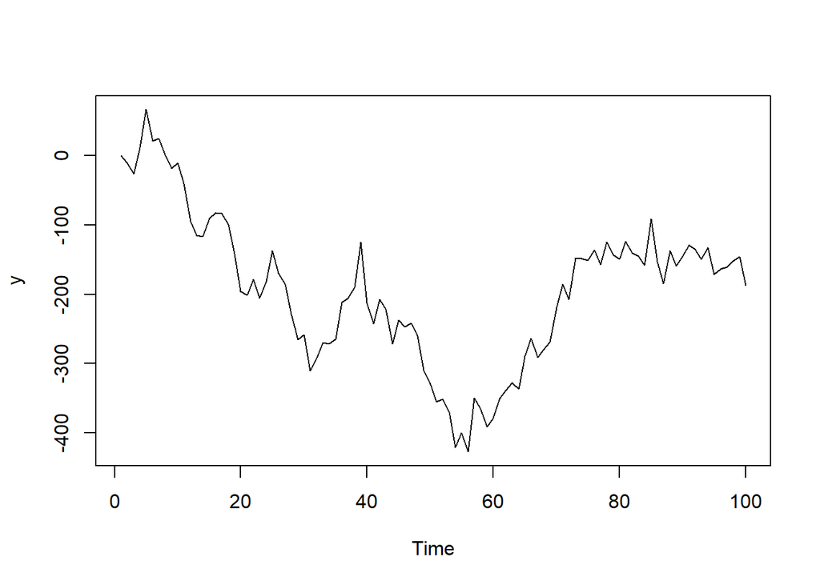

```r
n = 100
error_mean = 0
c <- rnorm(n, mean = error_mean, sd = 30)
y_0 = 0
y = c(y_0, 2:n)
for (i in 2:n)
{
  y[i] = y[i-1]+c[i]
}
y = ts(y)
plot(y)
```

- plot the ACF of the random walk

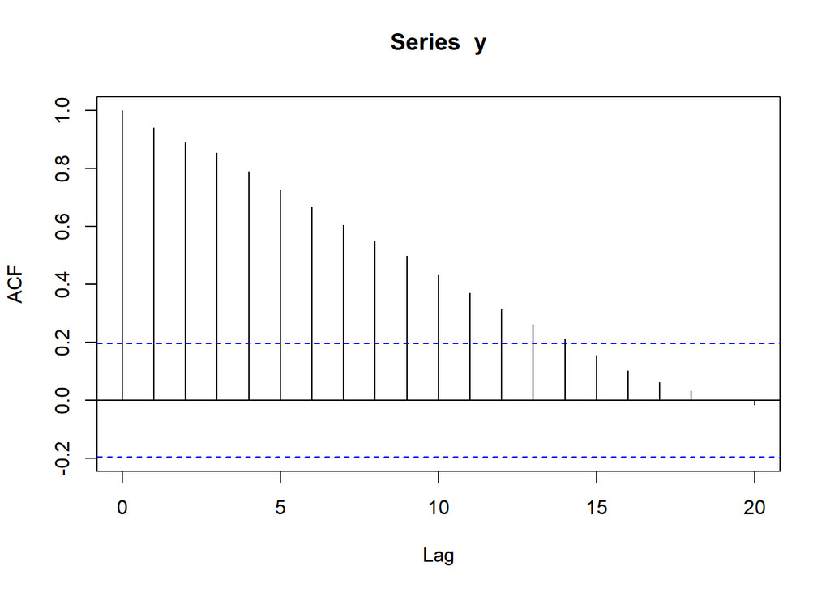

```r
acf(y)
```

- plot the differencing of Yt

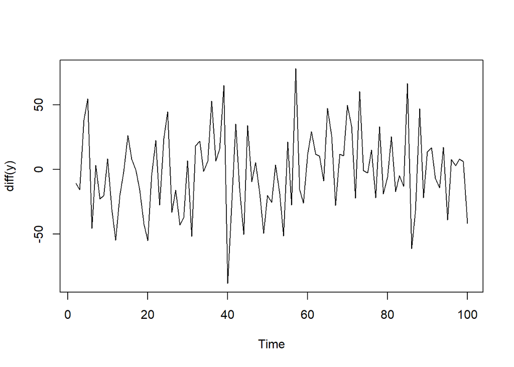

```r
plot(diff(y))
```

- plot the ACF of the differencing of Yt

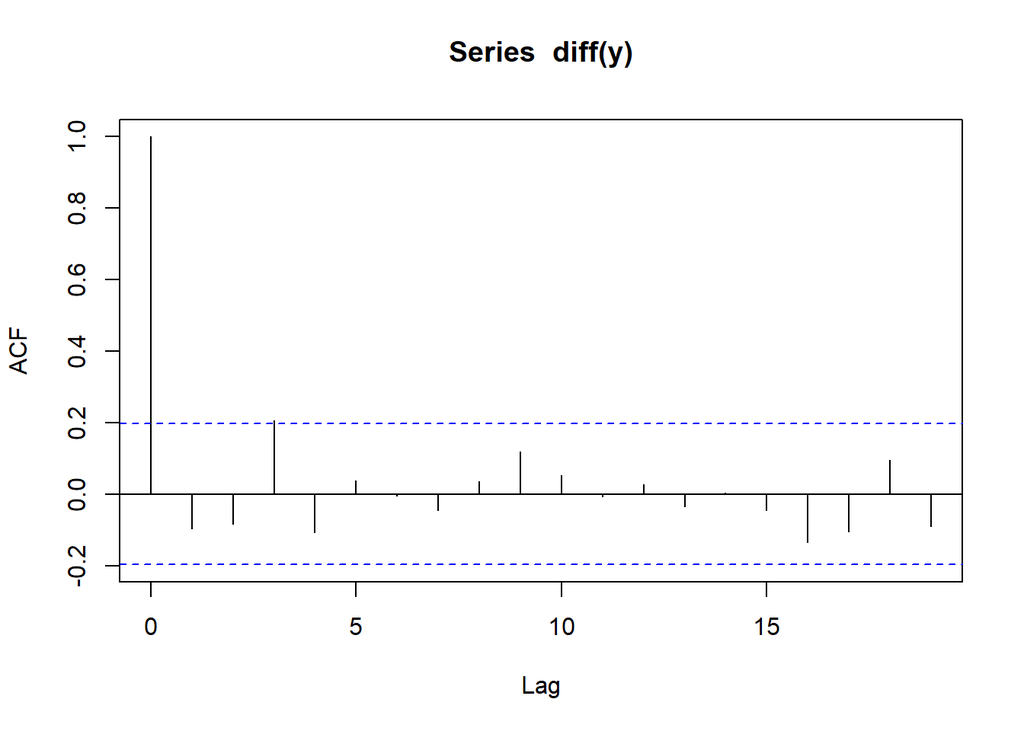

```r
acf(diff(y))
```